# Change Point Detection

A *Change Point* is a location in a time series where the true mean of the data exhibits a structural change, either as a jump (sudden change) or a kink (change in trend). Detecting change points is essential for flood frequency analysis (FFA), which assumes *trend-stationary* data. Therefore, annual maximum streamflow (AMS) must be split at change points to obtain trend-stationary segments. Due to the inherent variability of hydrological data, identifying change points can be challenging. To address this, the FFA framework provides two statistical tests:

- The Pettitt test, for sudden changes in the mean.
- The Mann-Kendall-Sneyers (MKS) test, for detecting changes in trend.

This vignette will demonstrate how these statistical tests can be used together to robustly identify change points in AMS data.

## Setup

We begin by loading the example dataset `Application_2.csv`, which has two columns:

- `max`: the AMS measurements
- `year`: the corresponding observation year

```r
library(ffaframework)
csv_path <- system.file("extdata", "Application_2.csv", package = "ffaframework")
df <- read.csv(csv_path)
```

## The Pettitt Test

The Pettitt test is a rank-based method for detecting a single abrupt change in the median of a time series. Under the null hypothesis, the time series has no change points.

Use the `eda_pettitt_test` function to perform the test. It requires two arguments:

- `data`: numeric vector of AMS measurements
- `years`: corresponding numeric vector of years

```r
pettitt_test <- eda_pettitt_test(df$max, df$year)

print(pettitt_test$p_value)
```

```
#> [1] 0
```

```r
print(pettitt_test$change_year)
```

```
#> [1] 1972
```

Since the Pettitt test returns a p-value of 0, we reject the null hypothesis and conclude that there is evidence of a change point in the year 1972. To visualize the result:

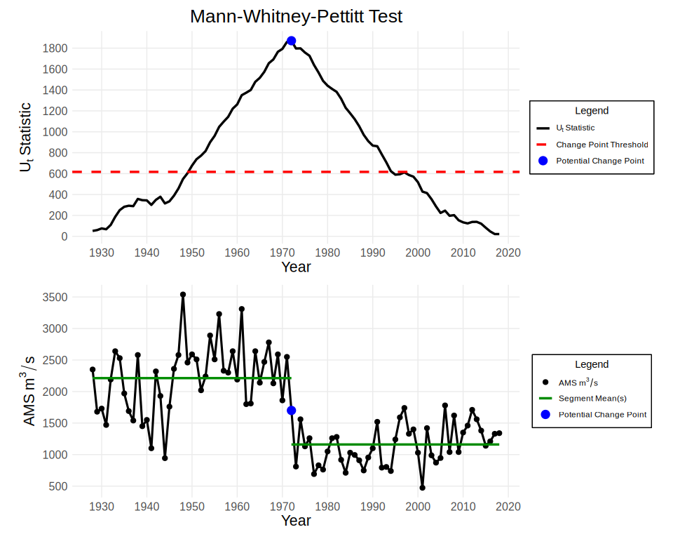

```r
plot_pettitt_test(pettitt_test)
```

## The MKS Test

The Mann-Kendall-Sneyers (MKS) test identifies trend changes in the AMS data. Unlike the Pettitt test, the MKS test can identify *multiple* change points.

Use `eda_mks_test` with the same arguments as above:

```r
mks_test <- eda_mks_test(df$max, df$year)

print(mks_test$p_value)
```

```
#> [1] 0.01495225
```

```r
print(mks_test$change_df$year)
```

```
#> [1] 1960 1985
```

The p-value reported corresponds to the most significant change point detected. The test may also return additional candidate years with weaker evidence.

To visualize the MKS results:

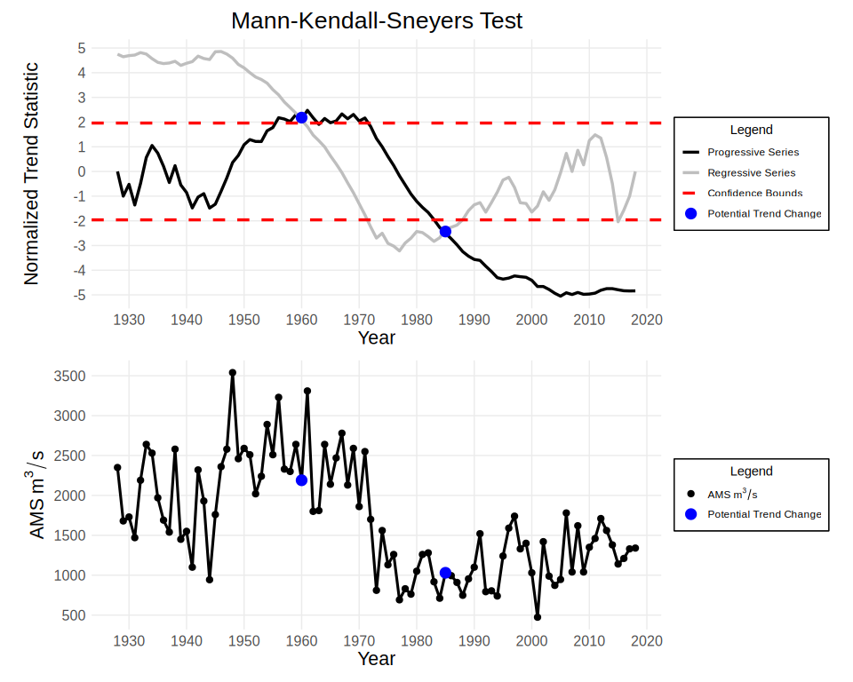

```r
plot_mks_test(mks_test)
```

## Interpreting and Selecting Change Points

In this example, the Pettitt and MKS tests both suggest structural changes in the time series. While the output is informative, selecting final change points requires careful judgment. Consider the following guidelines: